# Introduction to zenplots

M. Hofert and R. W. Oldford

2019-07-30

```r
library(zenplots)
```

# All pairs

A `zenplot` can show the same information as a `pairs` plot but with two important display differences.

First, the matrix organization of the `pairs` layout is replaced by the “zig-zag” layout of `zenplot`. Second, the number of plots produced is about half that of a `pairs` plot allowing each plot in a `zenplot` to be given more visual space.

## Producing all pairs with `PairViz`

A convenient function to produce all pairs can be found in the `PairViz` package found on `cran` and installed in `R` via `install.packages("PairViz")`.

```r
library(PairViz)
```

We will illustrate this functionality and the difference between a `pairs` plot and a `zenplot` by first considering a small dataset on earthquakes having only a few variates. The difference between the two plots becomes much more important for data having larger numbers of variates – we illustrate the difference again using German data on voting patterns in two elections.

### Example: Ground acceleration of earthquakes

The built-in `R` data set called `attenu` contains measurements to estimate the attenuating effect of distance on the ground acceleration of earthquakes in California.

There are 5 different variates used to describe the peak acceleration of 23 California earthquakes measured at different observation stations. The data set contains 182 different peak acceleration measurements and has some missing data. The first few cases of the data set look like

```r
head(attenu)
```

```
##   event mag station dist accel
## 1     1 7.0     117   12 0.359
## 2     2 7.4    1083  148 0.014
## 3     2 7.4    1095   42 0.196
## 4     2 7.4     283   85 0.135
## 5     2 7.4     135  107 0.062
## 6     2 7.4     475  109 0.054
```

Its variates are

```
## [1] "event"   "mag"     "station" "dist"    "accel"
```

and we are interested in all pairs of these variates.

To get these, first imagine a graph having as its nodes the variates of the data. An edge of this graph connects two nodes and hence represents a pair of variates. If interest lies in all pairs of varates, then the graph is a complete graph – it will have an edge between every pair of nodes. An ordering of variate pairs corresponds to any path on the graph. To have an ordering of all pairs of variates, the path must visit all edges and is called an Eulerian, or Euler path. Such a path always exists for complete graphs on an odd number of nodes; when the number of nodes is even, extra edges must be added to the graph before an Eulerian can exist.

For a complete graph with n nodes, the function `eseq` (for Euler sequence) function from the `PairViz` package returns an order in which the nodes (numbered 1 to n) can be visited to produce an Euler path. It works as follows.

```r
## Since attenu has 5 variates, the complete graph has n=5 nodes
## and an Euler sequence is given as
eseq(5)
```

```
##  [1] 1 2 3 1 4 2 5 3 4 5 1
```

In terms of the variate names of `attenu`, this is:

```r
names(attenu)[eseq(5)]
```

```
##  [1] "event"   "mag"     "station" "event"   "dist"    "mag"     "accel"
##  [8] "station" "dist"    "accel"   "event"
```

As can be seen in the corresponding complete graph below,

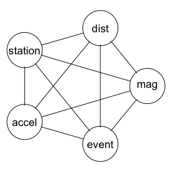

this sequence traces an Eulerian path on the complete graph and so presents every variate next to every other variate somewhere in the order.

#### Euler sequences via `zenpath`

This functionality (and more) from `PairViz` has been bundled together in the `zenplots` package as a single function `zenpath`. For example,

```r
zenpath(5)
```

```
##  [1] 5 1 2 3 1 4 2 5 3 4 5
```

This sequence, while still Eulerian, is slightly different than that returned by `eseq(5)`. The sequence is chosen so that all pairs involving the first index appear earliest in the sequence, then all pairs involving the second index, and so on. We call this a “front loaded” sequence and identify it with the `zenpath` argument `method = "front.loaded"`. Other possibilities are `method = "back.loaded"` and `method = "balanced"` giving the following sequences:

```r
## Back loading ensures all pairs appear latest (back) for
## high values of the indices.
zenpath(5, method = "back.loaded")
```

```
##  [1] 1 2 3 1 4 2 5 3 4 5 1
```

```r
## Frot loading ensures all pairs appear earliest (front) for
## low values of the indices.
zenpath(5, method = "front.loaded")
```

```
##  [1] 5 1 2 3 1 4 2 5 3 4 5
```

```r
## Balanced loading ensures all pairs appear in groups of all
## indices (Hamiltonian paths -> a Hamiltonian decomposition of the Eulerian)
zenpath(5, method = "balanced")
```

```
##  [1] 1 2 3 5 4 1 3 4 2 5 1
```

Analogously, “front loading” has the first (front) indices appear at the front of the sequence with their pairings appear as closely together as possible.

All three sequences are Eulerian, meaning all pairs appear somewhere in each sequence.

#### Pairs plots versus zenplots

Eulerian sequences can now be used to compare a `pairs` plot with a `zenplot` when all pairs of variates are to be displayed.

First a pairs plot:

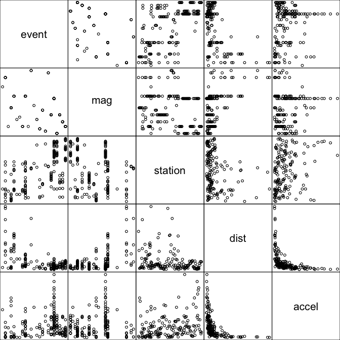

```r
## We remove the space between plots and suppress the axes
## so as to give maximal space to the individual scatterplots.
## We also choose a different plotting character and reduce
## its size to better distinguish points.
pairs(attenu, oma=rep(0,4), gap=0, xaxt="n", yaxt="n")
```

We now effect a display of all pairs using `zenplot`.

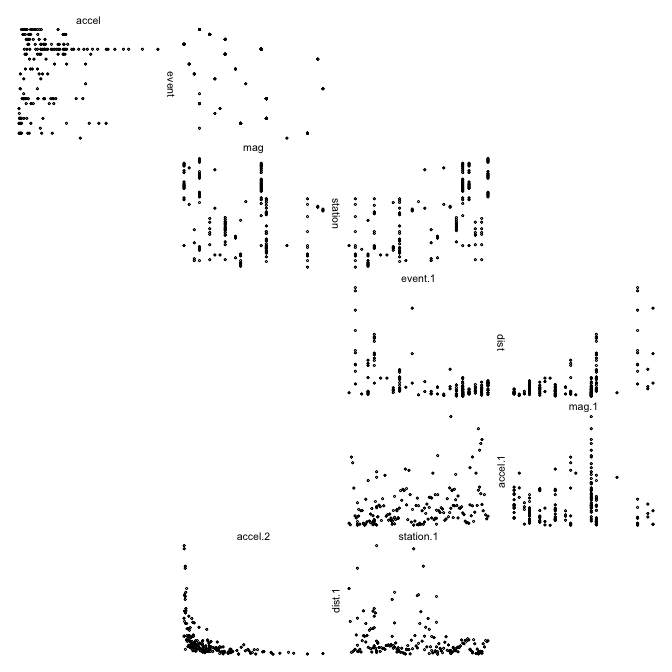

```r
## Plotting character and size are chosen to match that
## of the pairs plot.
## zenpath ensures that all pairs of variates appear
## in the zenplot.
## The last argument, n2dcol, is chosen so that the zenplot
## has the same number of plots across the page as does the
## pairs plot.
zenplot(attenu[, zenpath(ncol(attenu))], n2dcol=4)
```

Each display shows scatterplot of all `choose(5,2) =` 10 pairs of variates for this data. Each display occupies the same total area.

With `pairs` each plot is displayed twice and arranged in a symmetric matrix layout with the variate labels appearing along the diagonal. This makes for easy look-up but uses a lot of space.

With `zenplot`, each plot appears only once with its coordinate defining variates appearing as labels on horizontal (top or bottom) and vertical (left or right) axis positions. The layout follows the order of the variates in which the variates appear in the call to `zenplot` beginning in the top left corner of the display and then zig-zagging from top left to bottom right; when the rightmost boundary or the display is reached, the direction is reversed horizontally and the zigzag moves from top right to bottom left. The following display illustrates the pattern (had by simply calling `zenplot`):

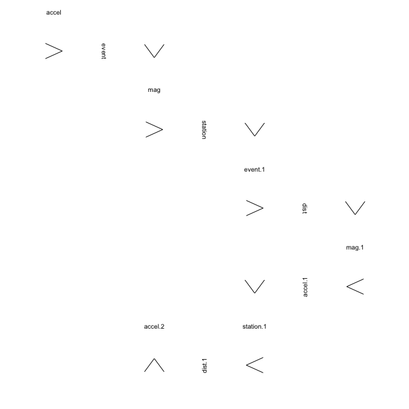

```r
## Call zenplot exactly as before, except that each scatterplot is replaced
## by an arrow that shows the direction of the layout.
zenplot(attenu[, zenpath(ncol(attenu))], plot2d="arrow", n2dcol=4)
```

The zig zag pattern of plots appears as follows.

Like the `pairs` plot, the `zenplot` lays its plots out on a two dimensional grid – the argument `n2dcol=4` specifies the number of columns for the 2d plots (e.g. scatterplots). As shown, this can lead to a lot of unused space in the display.

The `zenplot` layout can be made more compact by different choices of the argument `n2dcol` (odd values provide a more compact layout). For example,

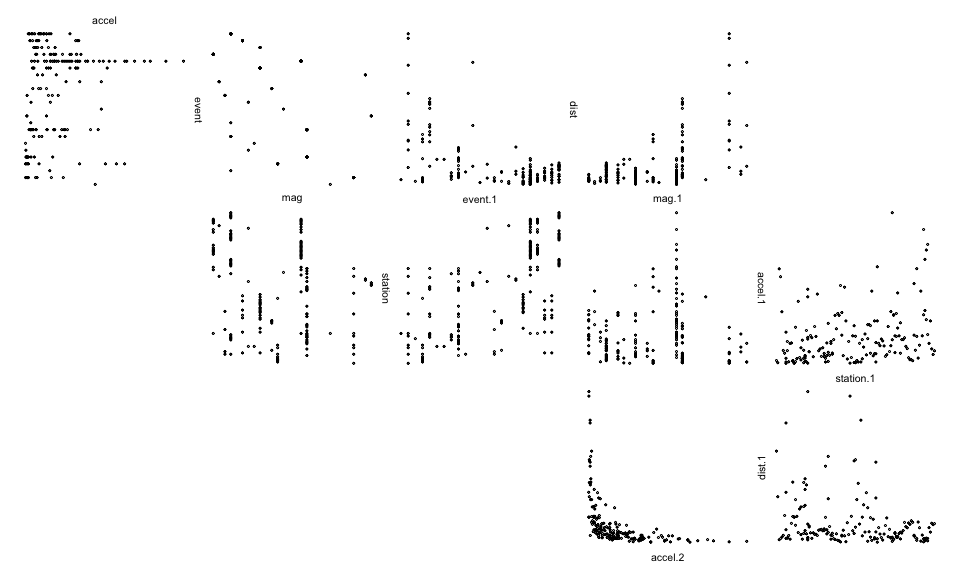

```r
## The default n2dcol is used
zenplot(attenu[, zenpath(ncol(attenu))], n2dcol=5)
```

By default, `zenplot` tries to determine a value for `n2dcol` that minimizes the space unused by its zigzag layout.

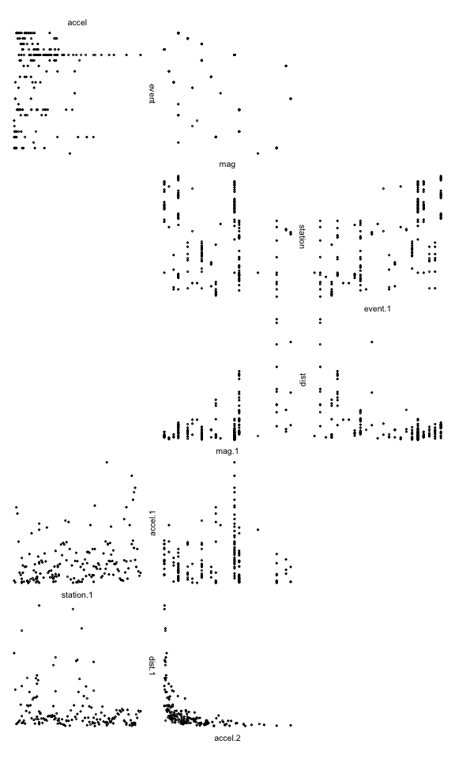

```r
## The default n2dcol is used
zenplot(attenu[, zenpath(ncol(attenu))])
```

with layout directions as

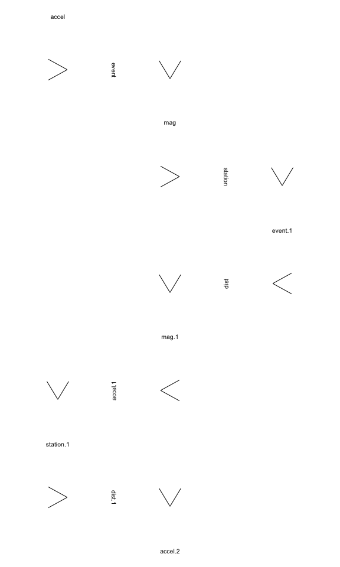

```r
## The directions
zenplot(attenu[, zenpath(ncol(attenu))], plot2d="arrow")
```

As the direction arrows show, the default layout is to zigzag horizontally first as much as possible.

This is clearly a much more compact display. Again, axes are shared wherever a label appears between plots.

### Visual search

The display arrangement of a scatterplot matrix facilitates the lookup of the scatterplot for any particular pair of variates by simply identifying the corresponding row and columns.

The scatterplot matrix also simplifies the visual comparison of the one variate to each of several others by scanning along any single row (or column). Note however that this single row scan does come at the price of doubling the number of scatterplots in the display.

These two visual search facilities are diminished by the layout of a `zenplot`. Although the same information is available in a `zenplot` the layout does not lend itself to easy lookup from variates to plots. If the `zenplot` layout is used in an interactive graphical system, other means of interaction could be implemented to have, for example, all plots containing a particular variate (or pair of variates) distinguish themselves visually by having their background colour change temporarily.

On the other hand, the reverse lookup from plot to variates is simpler in a `zenplot` than in a scatterplot matrix, particularly for large numbers of variates.

Both layouts allow a visual search for patterns in the point configurations. Having many plots be presented at once enables a quick visual search over a large space for the existence of interesting point configurations (e.g. correlations, outliers, grouping in data, lines, etc.).

When the number of plots is very large, an efficient compact layout can dramatically increase the size of the visual search space. This is where `zenplot`’s zigzag layout outperforms the scatterplot matrix.

This could be illustrated this on the following example.

### Example: German election data

In the `zenplots` package the data set `de_elect` contains the district results of two German federal elections (2002 and 2005) as well as a number of socio-economic variates as well.

```r
## Access the German election data from zenplots package
data(de_elect)
```

There are 299 districts and 68 variates yielding a possible `choose(68,2) =` 2278 different scatterplots.

This many scatterplots will overwhelm a `pairs` plot. In its most compact form, the pairs plot for the first 34 variates already occupies a fair bit of space:

```r
## pairs(de_elect[,1:34], oma=rep(0,4), gap=0, pch=".", xaxt="n", yaxt="n")
```

(N.B. We do not execute any of these large plots simply to keep the storage needs of this vignette to a minimum. We do encourage the reader to execute the code however on their own.)

If you execute the above code you will see interesting point configurations including: some very strong positive correlations, some positive and negative correlations, non-linear relations, the existence of some outlying points, clustering, striation, etc.

Because this scatterplot matrix is for only half of the variates it shows `choose(34,2) =` 561 different scatterplots, each one twice. For a display of 1122 plots, only about one quarter of all 2278 pairwise variate scatterplots available in the data set appear in this display.

A second scatterplot matrix on the remaining 34 variates would also show only a quarter of the plots. The remaining half, $34 \times 34 = 1156$ plots, are missing from both plots.

In contrast, the `zenplot` shows all 2278 plots at once. In fact, because an Eulerian sequence requires a graph to be even (i.e. each node has an even number of edges), whenever the number of variates, $p$, is even `zenpath(...)` will repeat exactly $p/2$ pairs somewhere in the sequence it returns.

To produce the `zenplot` of all pairs of variates on the German election data we call `zenplot(de_elect[,zenpath(68)], pch=".")`. (Again, we don’t produce it here so as to minimize the storage footprint of this vignette.)

```r
## Try invoking the plot with the following
## zenplot(de_elect[,zenpath(68)], pch=".", n2dcol="square",col=adjustcolor("black",0.5))
```

In contrast, all pairs loses most of the detail

```r
## pairs(de_elect, oma=rep(0,4), gap=0, pch=".", xaxt="n", yaxt="n",col=adjustcolor("black",0.5))
```

# Groups of pairwise plots

Zenplots also accomodate a list of data sets whose pairwise contents are to be displayed. The need for this can arise quite naturally in many applications.

The German election data, for instance, contains socio-economic data whose variates naturally group together. For example, we might gather variates related to education into one group and those related to employment into another.

```r
Education <- c("School.finishers",
               "School.wo.2nd", "School.2nd",
               "School.Real",  "School.UED")
Employment <- c("Employed", "FFF", "Industry",
                "CTT", "OS" )
```

We could plot all pairs for these two groups in a single `zenplot`.

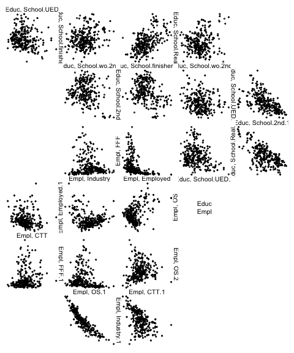

```r
EducationData <- de_elect[, Education]
EmploymentData <- de_elect[, Employment]

## Plot all pairs within each group
zenplot(list(Educ= EducationData[, zenpath(ncol(EducationData))],
             Empl= EmploymentData[, zenpath(ncol(EmploymentData))]))
```

All pairs of education variates are plotted first in zigzag order followed by a blank plot then continuing in the same zigzag pattern by plots all pairs of employment variates.

## All pairs by group

In addition to the `Education` and `Employment` groups above, a number of different groupings of variates having a shared context. For example, these might include the following:

```r
## Grouping variates in the German election data
Regions <- c("District", "State", "Density")
PopDist <- c("Men", "Citizens", "Pop.18.25", "Pop.25.35",
             "Pop.35.60", "Pop.g.60")
PopChange <- c("Births", "Deaths", "Move.in", "Move.out", "Increase")
Agriculture <- c("Farms", "Agriculture")
Mining <- c("Mining", "Mining.employees")
Apt <- c("Apt.new", "Apt")
Motorized <- c("Motorized")
Education <- c("School.finishers",
               "School.wo.2nd", "School.2nd",
               "School.Real",  "School.UED")
Unemployment <- c("Unemployment.03", "Unemployment.04")
Employment <- c("Employed", "FFF", "Industry", "CTT", "OS" )
Voting.05 <- c("Voters.05", "Votes.05", "Invalid.05", "Valid.05")
Voting.02 <- c("Voters.02", "Votes.02", "Invalid.02", "Valid.02")
Voting <- c(Voting.02, Voting.05)
VotesByParty.02 <- c("Votes.SPD.02", "Votes.CDU.CSU.02", "Votes.Gruene.02",
                     "Votes.FDP.02", "Votes.Linke.02")
VotesByParty.05 <- c("Votes.SPD.05", "Votes.CDU.CSU.05", "Votes.Gruene.05",
                     "Votes.FDP.05", "Votes.Linke.05")
VotesByParty <- c(VotesByParty.02, VotesByParty.05)
PercentByParty.02 <- c("SPD.02", "CDU.CSU.02", "Gruene.02",
                       "FDP.02", "Linke.02", "Others.02")
PercentByParty.05 <- c("SPD.05", "CDU.CSU.05", "Gruene.05",
                       "FDP.05", "Linke.05", "Others.05")
PercentByParty <- c(PercentByParty.02, PercentByParty.05)
```

The groups can now be used to explore internal group relations for many different groups in the same plot. Here the following helper function comes in handy.

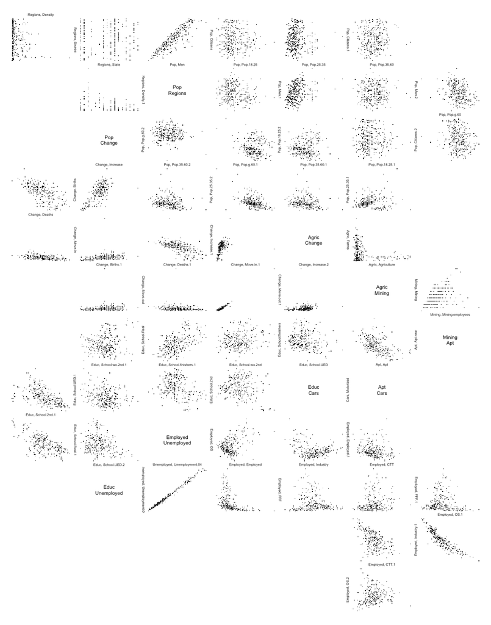

```r
groups <- list(Regions=Regions, Pop=PopDist,
               Change = PopChange, Agric=Agriculture,
               Mining=Mining, Apt=Apt,  Cars=Motorized,
               Educ=Education, Unemployed=Unemployment, Employed=Employment#,
               # Vote02=Voting.02, Vote05=Voting.05,
               # Party02=VotesByParty.02, Party05=VotesByParty.05,
               # Perc02=PercentByParty.02, Perc05=PercentByParty.05
               )

group_paths <- lapply(groups, FUN= function(g) g[zenpath(length(g), method = "front.loaded")] )
x <- groupData(de_elect, indices=group_paths)

zenplot(x, pch = ".", cex=0.7, col = "grey10")
```

All pairs within each group are presented following the zigzag pattern; each group is separated by an empty plot. The `zenplot` provides a quick overview of the pairwise relationships between variates within all groups.

The plot can be improved some by using shorter names for the variates. With a little work we can replace these within each group of `x`.

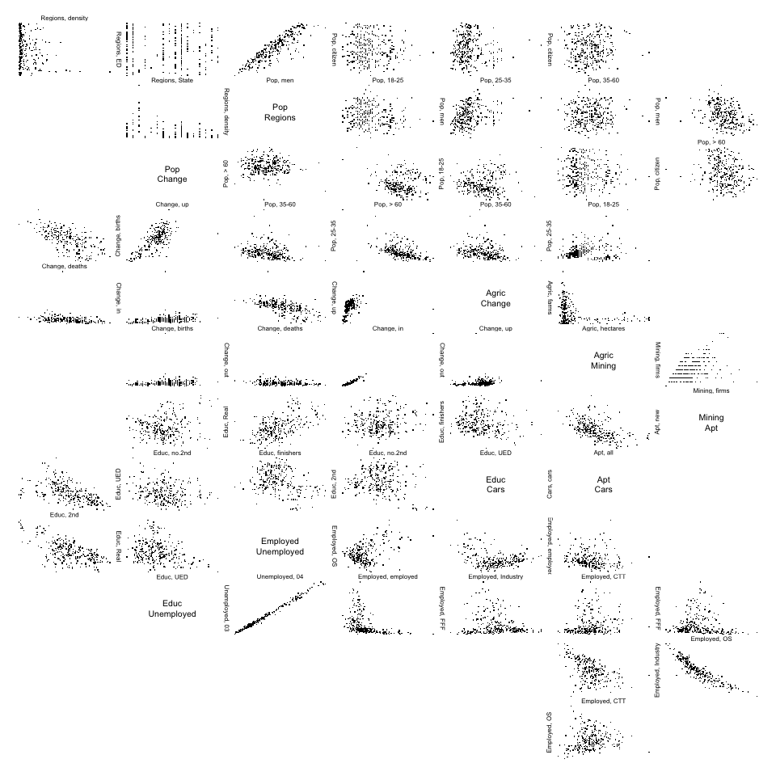

```r
#
## Grouping variates in the German election data
RegionsShort <- c("ED", "State", "density")
PopDistShort <- c("men", "citizen", "18-25", "25-35", "35-60", "> 60")
PopChangeShort <- c("births", "deaths", "in", "out", "up")
AgricultureShort <- c("farms", "hectares")
MiningShort <- c("firms", "employees")
AptShort <- c("new", "all")
TransportationShort <- c("cars")
EducationShort <- c("finishers", "no.2nd", "2nd", "Real", "UED")
UnemploymentShort<- c("03", "04")
EmploymentShort <- c("employed", "FFF", "Industry", "CTT", "OS" )
Voting.05Short <- c("eligible", "votes", "invalid", "valid")
Voting.02Short <- c("eligible", "votes", "invalid", "valid")
VotesByParty.02Short <- c("SPD", "CDU.CSU", "Gruene", "FDP", "Linke")
VotesByParty.05Short <- c("SPD", "CDU.CSU", "Gruene", "FDP", "Linke")
PercentByParty.02Short <- c("SPD", "CDU.CSU", "Gruene", "FDP", "Linke", "rest")
PercentByParty.05Short <-  c("SPD", "CDU.CSU", "Gruene", "FDP", "Linke", "rest")

shortNames <- list(RegionsShort, PopDistShort, PopChangeShort, AgricultureShort,
                   MiningShort, AptShort, TransportationShort, EducationShort,
                   UnemploymentShort, EmploymentShort, Voting.05Short, Voting.02Short,
                   VotesByParty.02Short, VotesByParty.05Short, PercentByParty.02Short,
                   PercentByParty.05Short)
# Now replace the names in x by these.

nGroups <- length(x)

for (i in 1:nGroups) {
  longNames <- colnames(x[[i]])
  newNames <- shortNames[[i]]
  oldNames <- groups[[i]]
  #print(longNames)
  #print(newNames)
  for (j in 1:length(longNames)) {
    for (k in 1:length(newNames)) {
      if (grepl(oldNames[k], longNames[j])) {
        longNames[longNames == longNames[j]] <- newNames[k]
      }
    }
  }
  colnames(x[[i]]) <- longNames
}

zenplot(x, pch = ".", cex=0.75)
```

## Crossing pairs between groups

It can also be of interest to compare variates between groups. For example, to compare the various levels of education with the employment categories.

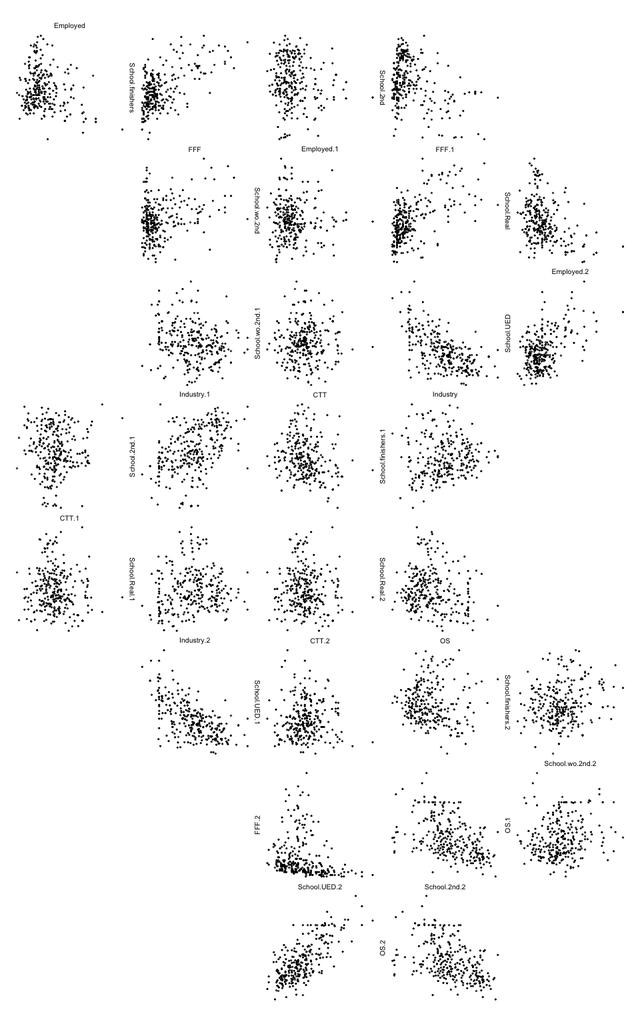

```r
crossedGroups <- c(Employment, Education)
crossedPaths <- zenpath(c(length(Employment), length(Education)), method="eulerian.cross")
zenplot(de_elect[,crossedGroups][crossedPaths])
```

# Other plots

A `zenplot` can be thought of as taking a data set whose variates are to be plotted in the order given. A sequence of one dimensional plots, as determined by the argument `plot1d`, are constructed in the order of the variates. Between each pair of these `1d` plots, a two dimensional plot is constructed from the variates of the `1d` plots. One variate provides the vertical `y` values and the other the horizontal `x` values. If the orientation of the preceding one-dimensional plot is horizontal, then that variate gives the `x` values; if it’s vertical then the vertical `y` coordinates.

## Built in `1d` and `2d` plots

The actual displays depend on the arguments `plot1d` and `plot2d`. There are numerous built-in choices provided.

For `plot1d` any of the following strings may be selected to produce a one-dimensional plot: `"label"`, `"rug"`, `"points"`, `"jitter"`, `"density"`, `"boxplot"`, `"hist"`, `"arrow"`, `"rect"`, `"lines"`. The first in the list is the default.

For `plot2d` any of the following strings can be given: `"points"`, `"density"`, `"axes"`, `"label"`, `"arrow"`, `"rect"`. Again, the first of these is the default value.

## Arbitrary layout using `turns`

For example, we could produce a `boxplot` for the measured variates of the earthquake data as follows:

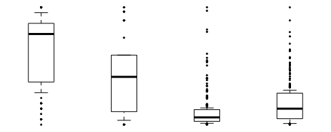

```r
earthquakes <- attenu[, c(1,2,4,5)]  # ignore the station id
zenplot(earthquakes,
        plot1d="boxplot", plot2d=NULL,
        width1d=5, width2d=1,
        turns=c("r","r","r","r","r","r","r"))
```

There are a few things to note here. First that every variate in the data set has a boxplot of its values presented and that the extent of boxplot display is that variate’s range. Second, the argument specification `plot2d=NULL` causes a null plot to be produced for each of the variate pairs. Third, the arguments `width1d` and `width2d` determine the relative widths of the two displays.

Finally, the argument `turns` determines the layout of the plots by specifying where the next display (`1d` or `2d`) is to appear in relation to the current one. Here every display appears to the right of the existing display.

An alternative layout of the same boxplots can be had by adjusting the `turns`.

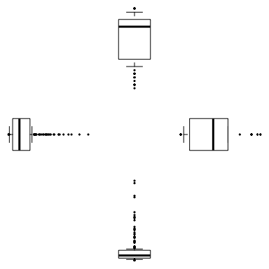

```r
zenplot(earthquakes,
        plot1d="boxplot", plot2d=NULL,
        width1d=1, width2d=1,  # now widths must be the same
        turns=c("r","d","d","l","l","u","u"))
```

To better see how the turns work, arrows could be used instead to show the directions of the turns.

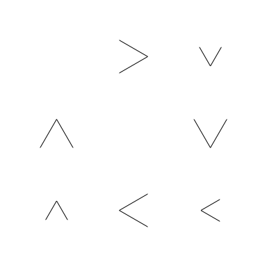

```r
zenplot(earthquakes,
        plot1d= "arrow", plot2d="arrow",
        width1d=1, width2d=2,
        turns=c("r","d","d","l","l","u","u"))
```

Adding a rectangle to outline the drawing space will make the layout a little clearer and illustrate the arguments that are passed on to the pne and two dimensional plot functions.

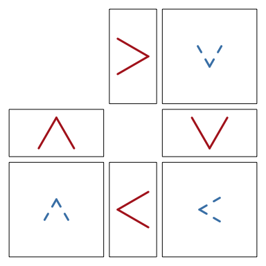

```r
zenplot(earthquakes,
        plot1d = function(zargs, ...) {
          rect_1d_graphics(zargs,  ...)
          arrow_1d_graphics(zargs, col="firebrick", lwd=3, add=TRUE, ...)
        },
        plot2d = function(zargs, ...) {
          rect_2d_graphics(zargs,  ...)
          arrow_2d_graphics(zargs, col="steelblue", lwd=3, lty=2, add=TRUE, ...)
        },
        width1d = 1, width2d = 2,
        turns=c("r","d","d","l","l","u","u"))
```

## Arbitrary plots

The above example also introduces some other important features of `zenplot`.

The value `"arrow"` of `plot2d` argument caused an arrow to be drawn wherever a `2d` plot was to appear in the direction of the turn associated with that plot. As the value of `plot1d` here suggests, the argument could also have been a function.

In fact, when given a string value for `plot2d`, `zenplot` calls a function whose name is constructed with this string. In the case of `plot2d = "arrow"`, `zenplot` calls the function `arrow_2d_graphics` to produce a `2d` plot whenever one is required. The naming convention constructs the function name from the string supplied, here “arrow”, the dimensionality of the plot (here `2d`) and the `R` graphics package that is being used (here the base `graphics` package). The function of that name is called on arguments appropriate to draw the plot.

The same construction is also used when a string is given as the value of the `plot1d` argument. For example `plot1d = "arrow"` causes the function named `arrow_1d_graphics` to be called to draw the `1d` plots.

Should, for example, the user wish to extend the base functionality of `zenplot` to include say `"myplot"`, they need only write functions `myplot_1d_graphics` and/or `myplot_2d_graphics` to allow the value `"myplot"` to be used for `plot1d` and/or `plot2d` in the base `graphics` package in `R`. Note that two other `R` plotting packages besides the base `graphics` are supported by `zenplot`, namely either the highly customizable `grid` package or the highly interactive `loon` package. The default package is `graphics` but either of the other two may be specified via the `pkg` argument to `zenplot` as in `pkg = "grid"` or `pkg = "loon"`.

When `zenplot` is called with `plot1d="arrow"`, say, then one of the functions `arrow_1d_graphics`, `arrow_1d_grid`, or `arrow_1d_loon` will be called upon depending on the value of the argument `pkg`. This means that a true extension of `zenplot` to include, say, `plot1d = "myplot"` would require writing three functions, namely `myplot_1d_graphics`, `myplot_1d_grid`, and `myplot_1d_loon`, to complete the functionality.

More often, as shown in the boxplot example, it will be a one-off functionality that might be required for either `plot2d` or `plot1d`.

### Example: mixing plots to assess distributions

`zenplot` can be used to layout graphics produced by any of the three `pkg` (i.e. `graphics`, `grid`, or `loon`) provided all graphics used are from the **same** package.

For example, suppose we were interested in the marginal distributions of the earthquake data. We might craft the following plot to investigate all marginal distributions and to compare each marginal to every other (i.e. all pairs).

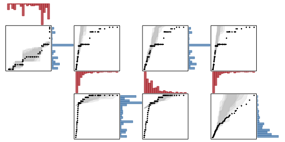

```r
library(qqtest)
zenplot(earthquakes[,zenpath(ncol(earthquakes))],
        width1d = 1, width2d = 2, n2dcol=5,
        plot1d = function(zargs, ...) {
          r <- extract_1d(zargs) # extract arguments for 1d
          col <- adjustcolor(if (r$horizontal) "firebrick" else "steelblue",
                             alpha.f = 0.7)
          hist_1d_graphics(zargs, col=col, ...)
          },
        plot2d=function(zargs, ...) {
          r <- extract_2d(zargs) # extract arguments for 2d
          x <- as.matrix(r$x)
          xlim <- r$xlim
          y <- as.matrix(r$y)
          ylim <- r$ylim
          qqtest(y, dataTest=x,
                 xlim=xlim, ylim=ylim,
                 cex=0.3, col="black",  pch=19,
                 legend=FALSE, main="", axes=FALSE, ...)

          })
```

As can be seen from the qqplots, since numerous points are outside the gray envelopes of each plot, no two marginal distributions would appear to be alike.

## Arguments to `plot1d` functions

Every `plot1d` function must take arbitrarily many arguments, accepting at least the following set:

- `x`, a vector of values for a single variate
- `horizontal`, which is `TRUE` if the `1d` plot is to be horizontal,
- `plotAsp`, the aspect ratio of the plot (i.e. the smaller/larger side ration in [0,1])
- `turn`, the single character turn out from the current plot
- `plotID`, a list containing information on the identification of the `plot`.

If the `plot1d` function is from the package `grid`, then it should also expect to receive a `vp` or viewport argument; if it is from the package `loon`, it might also receive a `parent` argument. These arguments should be familiar to users of either package.

For a `plot1d` function, the `plotID` consists of

- `group`, the number of the group in which this `1d` plot is placed,
- `number.within.group`, the within group index of this variate,
- `index` , the index of the variate among all variates in the data set(s)
- `label`, the variate label, and
- `plotNo`, the number of the `1d` plot being displayed (i.e its position in order among only those which are `1d`).

All other functions in the ellipsis, `...`, are passed on to the drawing functions.

## Arguments to `plot2d` functions

Every `plot2d` function must take arbitrarily many arguments, accepting at least the following set:

- `x`, a vector of values for the horizontal variate
- `y`, a vector of values for the vertical variate
- `turn`, the single character turn out from the current plot
- `plotID`, a list containing information on the identification of the `plot`.

If the `plot2d` function is from the package `grid`, then it should also expect to receive a `vp` or viewport argument; if it is from the package `loon`, it might also receive a `parent` argument. These arguments should be familiar to users of either package.

For a `plot2d` function, the `plotID` consists of

- `group`, the number of the group in which this `2d` plot is placed,
- `number.within.group`, the within group index for these variates (same index),
- `index` , the indices of the variates among all variates in the data set(s)
- `label`, the labels of the variates, and
- `plotNo`, the number of the `2d` the plot being displayed (i.e its position in order among only those which are `2d`).

All other functions in the ellipsis, `...`, are passed on to the drawing functions.